# Classification

Giorgos Tsalidis

1/31/2020

## Classification with Decision trees

A Decision Tree is a Machine Learning algorithm that is used mainly for classification problems. It can be applied to categorical and continuous data. The main concept of the algorithm is simple; the data are split consecutively according to certain splitting criteria.

Decision trees are computationally efficient when training and quite fast for classifying new instances. Furthermore, they are comprehensional when they are not too large, therefore they are frequently used for data exploration. A common pitfall is that they are sensitive to overfitting, which can be confronted by pruning or by adding further criteria when building the tree.

```r
library(rpart)
library(rpart.plot)
weather=read.csv("../data/weather.txt")
```

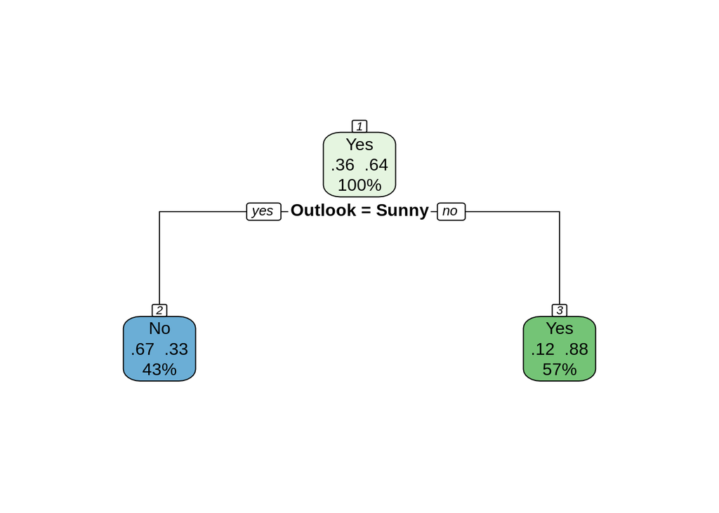

```r
#To see the split for the variable Outlook, execute the following command
model<-rpart(Play~Outlook, method="class", data=weather, minsplit=1)
rpart.plot(model, extra = 104, nn = TRUE)
```

```r
absfreq=table(weather[,c(1,4)])
freq=prop.table(absfreq,1)
freqSum=rowSums(prop.table(absfreq))
```

```r
#calculate the Gini index for Sunny and Rainy
GINI_Sunny=1-freq["Sunny","No"]^2-freq["Sunny","Yes"]^2
GINI_Rainy=1-freq["Rainy","No"]^2-freq["Rainy","Yes"]^2

#The total Gini for Outlook is computed by
```

```r
GINI_Outlook=freqSum["Sunny"]*GINI_Sunny+freqSum["Rainy"]*GINI_Rainy
```

Initially, we compute the total entropy of the dataset:

```r
freq = prop.table(table(weather[, c(4)]))
Entropy_All = - freq["No"] * log(freq["No"]) - freq["Yes"] * log(freq["Yes"])
```

Then, for Outlook, we build the following frequency arrays:

```r
absfreq = table(weather[, c(1, 4)])
freq = prop.table(absfreq, 1)
freqSum = rowSums(prop.table(absfreq))
```

We calculate the entropy for Sunny and Rainy:

```r
#calculate the entropy for Sunny and Rainy
Entropy_Sunny=-freq["Sunny","No"]*log(freq["Sunny","No"])-freq["Sunny","Yes"]*log(freq["Sunny","Yes"])
Entropy_Rainy=-freq["Rainy","No"]*log(freq["Rainy","No"])-freq["Rainy","Yes"]*log(freq["Rainy","Yes"])
```

The total information gain for Outlook is computed by:

```r
#the tolat information for Outlook
GAIN_Outlook=Entropy_All-freqSum["Sunny"]*Entropy_Sunny-freqSum["Rainy"]*Entropy_Rainy
```

```r
# Building the Decision Tree using rpart
model<-rpart(Play~Outlook+Temperature+Humidity,
             method="class",
             data=weather,
             minsplit=1,
             minbucket=1,
             cp=-1)
```

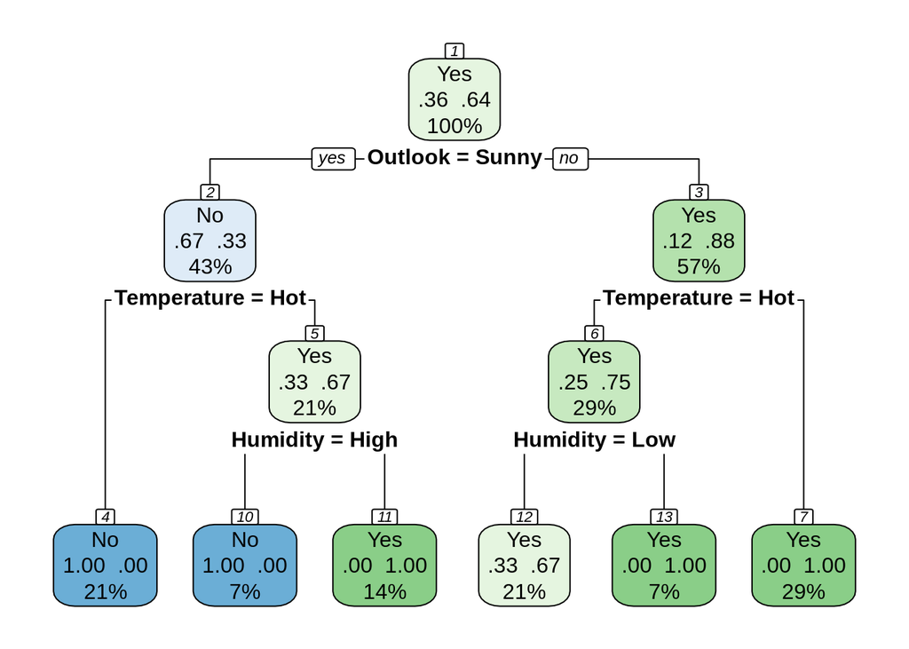

```r
rpart.plot(model, extra = 104, nn = TRUE)
```

## Application with Pruning and Evaluation Metrics

```r
iris2 = iris[, c(1, 2, 5)]
iris2$Species[c(101:150)] = iris2$Species[c(21:70)]
iris2$Species = factor(iris2$Species)
```

After that, we split the dataset into training and testing data:

```r
trainingdata = iris2[c(1:40, 51:90, 101:140),]
testdata = iris2[c(41:50, 91:100, 141:150),]
```

train the decision tree and plot it using the following commands

```r
#Build a decision tree using the training data (the minsplit parameter of rpart should be set to20, which is the default)
model<-rpart(Species~., #The . in the formula stands for all the remaining variables in the data frame trainingdata
             method="class",
             data=trainingdata,
             minsplit=20)
```

Visualise model

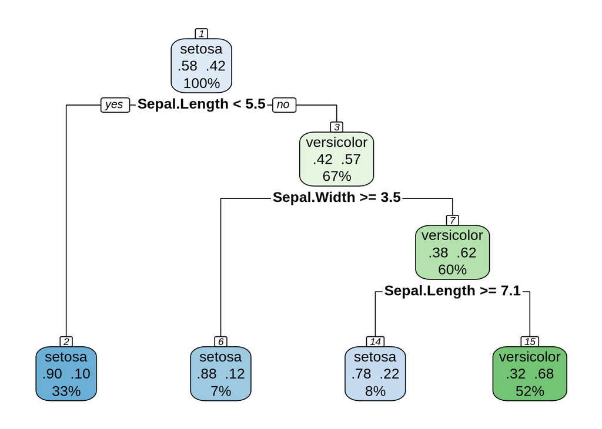

```r
rpart.plot(model, extra = 104, nn = TRUE)
```

Execute on test set

```r
xtest = testdata[,1:2]
ytest = testdata[,3]
pred = predict(model, xtest, type="class")
```

## Evaluation Metrics

```r
library(MLmetrics)
cm = ConfusionMatrix(pred, ytest)
accuracy = Accuracy(pred, ytest)
precision = Precision(ytest, pred, 'versicolor')
recall = Recall(ytest, pred, 'versicolor')
f1 = F1_Score(ytest, pred, 'versicolor')
data.frame(precision, recall, f1)
```

```
##   precision recall        f1
## 1         1    0.9 0.9473684
```

## Classification with Naive Bayes

```r
traffic = read.csv("../data/traffic.txt")
library(e1071)
traffic
```

```
##   Weather      Day HighTraffic
## 1     Hot Vacation          No
## 2    Cold     Work         Yes
## 3  Normal     Work          No
## 4    Cold  Weekend         Yes
## 5  Normal  Weekend         Yes
## 6    Cold     Work          No
## 7     Hot     Work          No
## 8     Hot Vacation         Yes
```

### Building Simple Model

```r
model <- naiveBayes(HighTraffic ~ ., data = traffic)
print(model)
```

```
##
## Naive Bayes Classifier for Discrete Predictors
##
## Call:
## naiveBayes.default(x = X, y = Y, laplace = laplace)
##
## A-priori probabilities:
## Y
##  No Yes
## 0.5 0.5
##
## Conditional probabilities:
##      Weather
## Y     Cold  Hot Normal
##   No  0.25 0.50   0.25
##   Yes 0.50 0.25   0.25
##
##      Day
## Y     Vacation Weekend Work
##   No      0.25    0.00 0.75
##   Yes     0.25    0.50 0.25
```

classify a new instance with values (Weather, Day) = (Hot, Vacation)

```r
trvalue <- data.frame(Weather = factor("Hot", levels(traffic$Weather)),
factor("Vacation", levels(traffic$Day)))
predict(model, trvalue)
```

```
## [1] No
## Levels: No Yes
```

We can also get the relevant probabilities

```r
predict(model, trvalue, type = "raw")
```

```
##             No       Yes
## [1,] 0.6666667 0.3333333
```

Apply the Naive Bayes classifier on the dataset HouseVotes84. Initially, we import the dataset, ignoring any instances with missing values

```r
library(e1071)
library(MLmetrics)
library(ROCR)
data(HouseVotes84, package = "mlbench")
votes = na.omit(HouseVotes84)

#split the dataset into training and testing data:
trainingdata = votes[1:180,]
testingdata = votes[181:232,]
```

### Building and Applying the Naive Bayes Model

```r
model <- naiveBayes(Class ~ ., data = trainingdata)

xtest = testingdata[,-1]
ytest = testingdata[,1]
pred = predict(model, xtest)
predprob = predict(model, xtest, type = "raw")
```

### Metrics Computation and ROC Curve Plotting

```r
ConfusionMatrix(ytest, pred)
```

```
##             y_pred
## y_true       democrat republican
##   democrat         20          1
##   republican        5         26
```

```r
Precision(ytest, pred, "democrat")
```

```
## [1] 0.952381
```

```r
Recall(ytest, pred)
```

```
## [1] 0.8
```

Plotting the ROC curve (question (c)) initially requires computing TPR and FRP with the following commands:

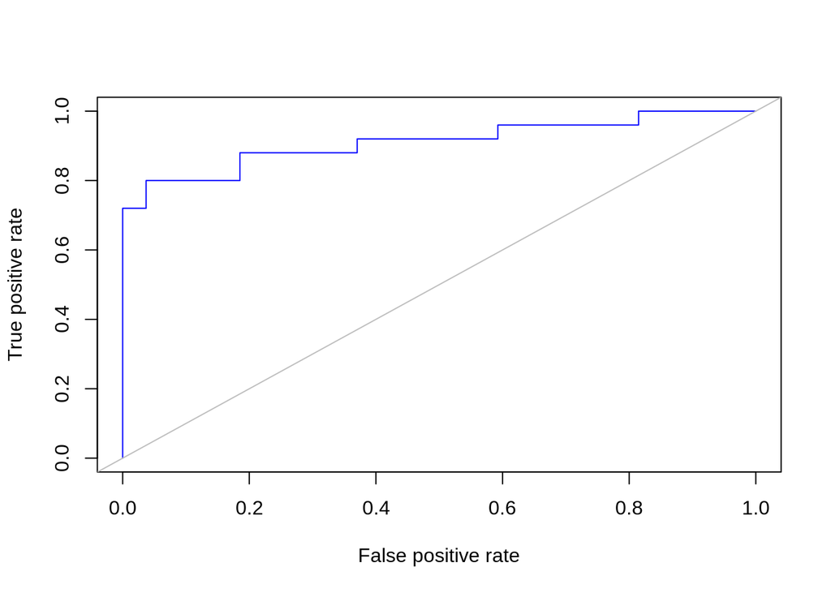

```r
pred_obj = prediction(predprob[,1], ytest, label.ordering = c("republican", "democrat"))
ROCcurve <- performance(pred_obj, "tpr", "fpr")

plot(ROCcurve, col = "blue")
abline(0,1, col = "grey")
```

```r
performance(pred_obj, "auc")
```

```
## An object of class "performance"
## Slot "x.name":
## [1] "None"
##
## Slot "y.name":
## [1] "Area under the ROC curve"
##
## Slot "alpha.name":
## [1] "none"
##
## Slot "x.values":
## list()
##
## Slot "y.values":
## [[1]]
## [1] 0.9111111
##
##
## Slot "alpha.values":
## list()
```

k-Nearest Neighbors (kNN) is a machine learning algorithm, where the prediction for a new instance depends on its k nearest instances. As a result, the class for a new instance is determined by majority vote given the class of its k nearest instances.

Breast Cancer Wisconsin (Original) Data Set For this example we are going to use the Breast Cancer Wisconsin (Original) Data Set9 and in particular the breast-cancer-wisconsin.data file10 from the UCI Machine Learning Repository11

```r
rm(list=ls())
# download the dataset
fileURL <- "http://archive.ics.uci.edu/ml/machine-learning-databases/breast-cancer-wisconsin/breast-cancer-wisconsin.data"
#download.file(fileURL, destfile="../data/breast-cancer-wisconsin.data")
# read the data
data <- read.table("../data/breast-cancer-wisconsin.data", na.strings = "?", sep=",")
# remove the id column
data <- data[,-1]
# put names in the columns (attributes)
names(data) <- c("ClumpThickness",
"UniformityCellSize",
"UniformityCellShape",
"MarginalAdhesion",
"SingleEpithelialCellSize",
"BareNuclei",
"BlandChromatin",
"NormalNucleoli",
"Mitoses",
"Class")
# make the class a factor
data$Class <- factor(data$Class, levels=c(2,4), labels=c("benign", "malignant"))
# set the seed
set.seed(1)
# split the dataset
ind <- sample(2, nrow(iris), replace=TRUE, prob=c(0.7, 0.3))
trainData <- data[ind==1,]
validationData <- data[ind==2,]
```

### Training & Prediction

```r
library(class)

trainData <- trainData[complete.cases(trainData),]
validationData <- validationData[complete.cases(validationData),]
trainDataX <- trainData[,-ncol(trainData)]
trainDataY <- trainData$Class
validationDataX <- validationData[,-ncol(trainData)]
validationDataY <- validationData$Class
```

### Prediction

```r
prediction = knn(trainDataX, validationDataX, trainDataY, k = 1)
```

### Evaluation

```r
cat("Confusion matrix:\n")
```

```
## Confusion matrix:
```

```r
xtab = table(prediction, validationData$Class)
print(xtab)
```

```
##
## prediction  benign malignant
##   benign       126         6
##   malignant      4        66
```

```r
cat("\nEvaluation:\n\n")
```

```
##
## Evaluation:
```

```r
accuracy = sum(prediction == validationData$Class)/length(validationData$Class)
precision = xtab[1,1]/sum(xtab[,1])
recall = xtab[1,1]/sum(xtab[1,])
f = 2 * (precision * recall) / (precision + recall)
cat(paste("Accuracy:\t", format(accuracy, digits=2), "\n",sep=" "))
```

```
## Accuracy:     0.95
```

```r
cat(paste("Precision:\t", format(precision, digits=2), "\n",sep=" "))
```

```
## Precision:    0.97
```

```r
cat(paste("Recall:\t\t", format(recall, digits=2), "\n",sep=" "))
```

```
## Recall:       0.95
```

```r
cat(paste("F-measure:\t", format(f, digits=2), "\n",sep=" "))
```

```
## F-measure:    0.96
```

### Classification with Support Vector Machines

If the data are not linearly separable, then they can be mapped to a space of different (usually larger) dimensionality, in order to make them linearly separable.

```r
library(MLmetrics)
library(e1071)

#load the dataset as a dataframe
rm(list=ls())
# download the dataset
fileURL<-"https://media.geeksforgeeks.org/wp-content/uploads/social.csv"
#download.file(fileURL, destfile="../data/social.csv") # uncomment to download
```

```r
# Importing the dataset
dataset = read.csv('../data/social.csv')

# Taking columns 3-5
dataset = dataset[3:5]

# Encoding the target feature as factor
dataset$Purchased = factor(dataset$Purchased, levels = c(0, 1))
```

```r
# Splitting the dataset into the Training set and Test set
#install.packages('caTools')
library(caTools)

set.seed(123)
split = sample.split(dataset$Purchased, SplitRatio = 0.75)

training_set = subset(dataset, split == TRUE)
test_set = subset(dataset, split == FALSE)
```

```r
# Feature Scaling
training_set[-3] = scale(training_set[-3])
test_set[-3] = scale(test_set[-3])
```

```r
# Fitting SVM to the Training set
#install.packages('e1071')
library(e1071)

classifier = svm(formula = Purchased ~ .,
                 data = training_set,
                 type = 'C-classification',
                 kernel = 'linear')

# Predicting the Test set results
y_pred = predict(classifier, newdata = test_set[-3])
print(y_pred)
```

```
##   2   4   5   9  12  18  19  20  22  29  32  34  35  38  45  46  48  52  66  69
##   0   0   0   0   0   0   0   0   0   0   0   0   0   0   0   0   0   0   0   0
##  74  75  82  84  85  86  87  89 103 104 107 108 109 117 124 126 127 131 134 139
##   0   0   0   0   0   0   0   0   0   1   0   0   0   0   0   0   0   0   0   0
## 148 154 156 159 162 163 170 175 176 193 199 200 208 213 224 226 228 229 230 234
##   0   0   0   0   0   0   0   0   0   0   0   0   1   1   1   0   1   0   1   1
## 236 237 239 241 255 264 265 266 273 274 281 286 292 299 302 305 307 310 316 324
##   1   0   1   1   1   0   1   1   1   1   1   0   1   1   1   0   1   0   0   0
## 326 332 339 341 343 347 353 363 364 367 368 369 372 373 380 383 389 392 395 400
##   0   1   0   1   0   1   1   0   1   1   1   0   1   0   1   1   0   0   0   0
## Levels: 0 1
```

```r
# Making the Confusion Matrix
cm = table(test_set[, 3], y_pred)
```

```r
library(ElemStatLearn)

# Plotting the training data set results
set = training_set
X1 = seq(min(set[, 1]) - 1, max(set[, 1]) + 1, by = 0.01)
X2 = seq(min(set[, 2]) - 1, max(set[, 2]) + 1, by = 0.01)

grid_set = expand.grid(X1, X2)
colnames(grid_set) = c('Age', 'EstimatedSalary')
y_grid = predict(classifier, newdata = grid_set)
```

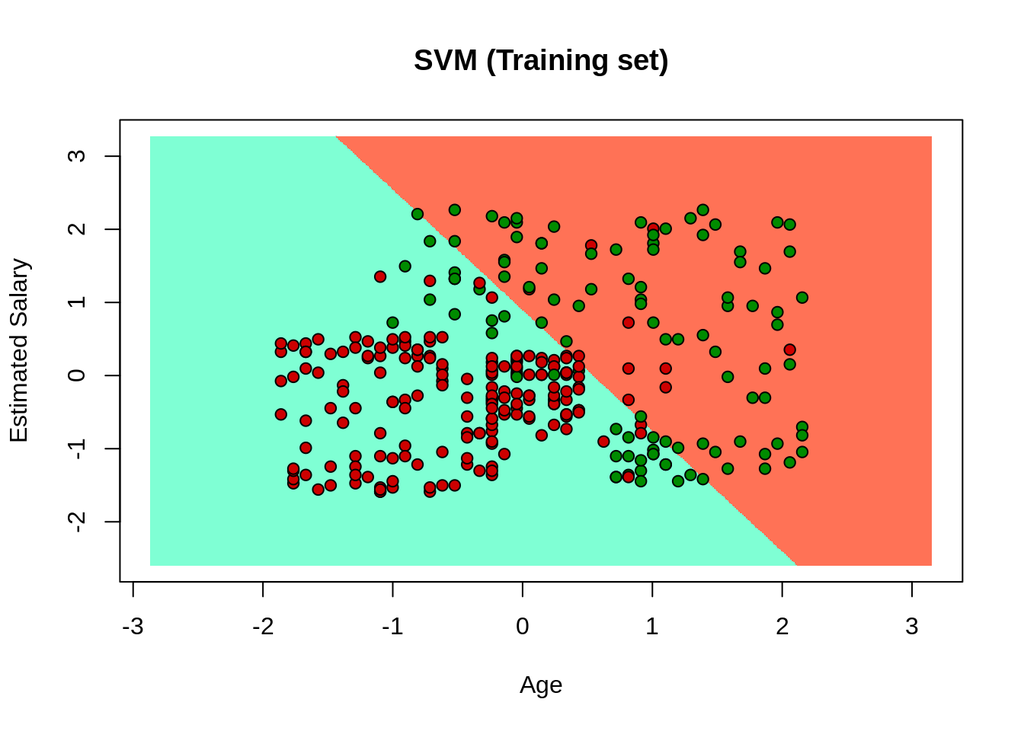

```r
plot(set[, -3],
     main = 'SVM (Training set)',
     xlab = 'Age', ylab = 'Estimated Salary',
     xlim = range(X1), ylim = range(X2))

contour(X1, X2, matrix(as.numeric(y_grid), length(X1), length(X2)), add = TRUE)

points(grid_set, pch = '.', col = ifelse(y_grid == 1, 'coral1', 'aquamarine'))

points(set, pch = 21, bg = ifelse(set[, 3] == 1, 'green4', 'red3'))
```

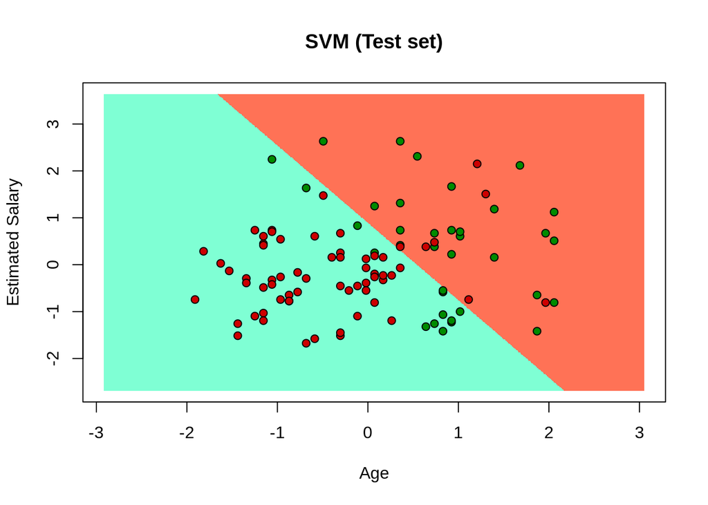

```r
#Visualizing the Test set results

set = test_set
X1 = seq(min(set[, 1]) - 1, max(set[, 1]) + 1, by = 0.01)
X2 = seq(min(set[, 2]) - 1, max(set[, 2]) + 1, by = 0.01)

grid_set = expand.grid(X1, X2)
colnames(grid_set) = c('Age', 'EstimatedSalary')
y_grid = predict(classifier, newdata = grid_set)

plot(set[, -3], main = 'SVM (Test set)',
     xlab = 'Age', ylab = 'Estimated Salary',
     xlim = range(X1), ylim = range(X2))

contour(X1, X2, matrix(as.numeric(y_grid), length(X1), length(X2)), add = TRUE)

points(grid_set, pch = '.', col = ifelse(y_grid == 1, 'coral1', 'aquamarine'))

points(set, pch = 21, bg = ifelse(set[, 3] == 1, 'green4', 'red3'))
```

```r
cm
```

```
##    y_pred
##      0  1
##   0 57  7
##   1 13 23
```